# Third Week: Exploratory Data Analysis

در بازی هایی که Real Madrid برده است، تفاوت میانگین تفاضل گل در خانه خود و خونه حریف چه بوده است؟

```r
# 10_1

fdb%>%filter(home=="Real Madrid")%>%mutate(Gd=hgoal-vgoal)%>%filter(Gd>0)%>%select(Season,Opp=visitor,Gd)->stat10_0
fdb%>%filter(visitor=="Real Madrid")%>%mutate(Gd=vgoal-hgoal)%>%filter(Gd>0)%>%select(Season,Opp=home,Gd)->stat10_1
ha=as.data.frame(c(home_mean = mean(stat10_0$Gd),visiting_mean = mean(stat10_1$Gd)))
names(ha)="meanGoalDiff"
ha$name=as.factor(c("home_mean","visiting_mean"))
ha%>%hchart(type = "bar",hcaes(x=name,y=meanGoalDiff))
```

[interactive chart not shown]

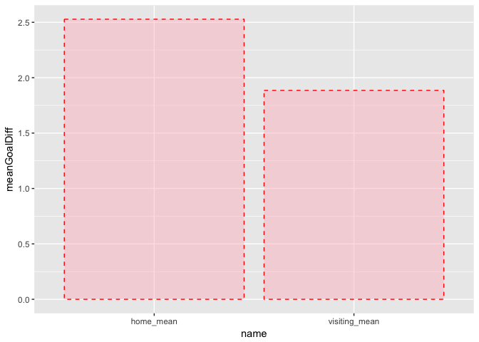

```r
p10_1=ggplot(ha,aes(x=name,y=meanGoalDiff))+geom_col(linetype = "dashed",color = "red",fill = "pink",alpha=0.5)
p10_1
```

در بازی هایی که باخته است تفاوت تفاضل گل در خانه خود و یا حریف چه قدر بوده؟ آیا در خانه ی حریف شکست ها سنگین تر اند؟

```r
fdb%>%filter(home=="Real Madrid")%>%mutate(Gd=hgoal-vgoal)%>%filter(Gd<0)%>%select(Season,Opp=visitor,Gd)->stat10_2
fdb%>%filter(visitor=="Real Madrid")%>%mutate(Gd=vgoal-hgoal)%>%filter(Gd<0)%>%select(Season,Opp=home,Gd)->stat10_3
ha1=as.data.frame(c(home_mean = mean(stat10_2$Gd),visiting_mean = mean(stat10_3$Gd)))
names(ha1)="meanGoalDiff"
ha1$name=as.factor(c("home_mean","visiting_mean"))
ha1%>%hchart(type = "bar",hcaes(x=name,y=meanGoalDiff))
```

[interactive chart not shown]

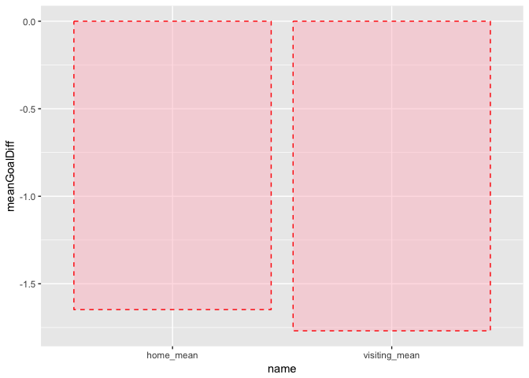

```r
p10_2=ggplot(ha1,aes(x=name,y=meanGoalDiff))+geom_col(linetype = "dashed",color = "red",fill = "pink",alpha=0.5)
p10_2
```

در بازی هایی که نیمه ی اول با شکست Real Madrid پایان یافته و سپس در نهایت Real Madrid پیروز میدان بوده، تفاضل گل در بازی های خانگی و بازی ها در خانه ی حریف متفاوت است؟

```r
fdb$Hvgoal=as.numeric(substr(fdb$HT, 3, 4))
fdb$Hhgoal=as.numeric(substr(fdb$HT, 1, 1))

fdb%>%filter(home=="Real Madrid")%>%mutate(Gd=hgoal-vgoal,Gdh=Hhgoal-Hvgoal)%>%
  filter(Gdh<0)%>%filter(Gd>0)%>%select(Season,Opp=visitor,Gd,Gdh)->stat10_4


fdb%>%filter(visitor=="Real Madrid")%>%mutate(Gd=vgoal-hgoal,Gdh=Hvgoal-Hhgoal)%>%
  filter(Gdh<0)%>%filter(Gd>0)%>%select(Season,Opp=visitor,Gd,Gdh)->stat10_5

ha2=as.data.frame(c(home_mean = mean(stat10_4$Gd),visiting_mean = mean(stat10_5$Gd)))
names(ha2)="meanGoalDiff"
ha2$name=as.factor(c("home_mean","visiting_mean"))
ha2%>%hchart(type = "bar",hcaes(x=name,y=meanGoalDiff))
```

[interactive chart not shown]

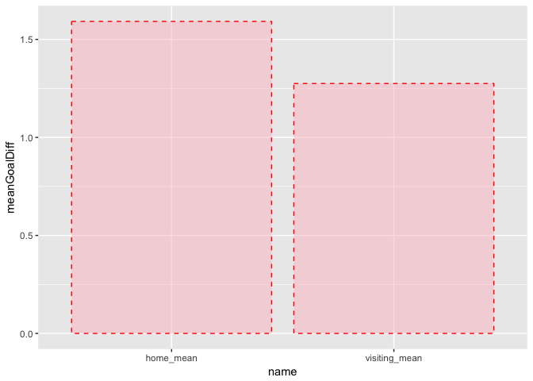

```r
p10_3=ggplot(ha2,aes(x=name,y=meanGoalDiff))+geom_col(linetype = "dashed",color = "red",fill = "pink",alpha=0.5)
p10_3
```